# HW 3

Homa, Claudia, Amanda, Michelle

March 17, 2019

### **Ex. 3.6 (Chapter 3, page 95)**

*Question: Show that the ridge regression estimate is the mean (and mode) of the posterior distribution, under a Gaussian prior $\beta ~ N(0,\tau^2 I)$, and Gaussian sampling model $y~N(X\beta,\sigma^2 I)$. Find the relationship between the regularization parameter $\lambda$ in the ridge formula, and the variances $\tau$ and $\sigma^2$.*

*Answer:* The ridge regression estimate is given by: $\beta = (X^TX+\lambda I)^{-1}X^TY$ and is obtained by minimizing the $RSS(\lambda,\beta)$ function subject to a constraint that penalizes the coefficients. Alternatively, the coefficients can be obtained by computing the mean of the posterior distribution with a known Gaussian prior.

According to Bayes’ Rule, the posterior probability ($P(\beta|Y,X)$) is proportional to the likelihood ($P(Y,X|\beta)$) and the prior ($P(Y,X)$).
$$P(\beta|Y,X) = \frac{P(Y,X|\beta)P(\beta)}{P(Y,X)}$$
Given that $Y$ and $\beta$ are normally distributed with $N(X^T\beta,\sigma^2 I)$ and $N(0,\tau^2 I)$ respectively, then posterior probability must also be normally distributed.

With these assumptions in mind, the mean of the posterior probability can thus be estimated via the maximum a posteriori estimate technique (similar to MLE, but with a known information about the prior distribution). Since the $P(Y,X)$ does not depend on $\beta$, then the maximization problem becomes:

$$max_{\beta} P(Y,X|\beta)P(\beta)$$

$$max_{\beta} \frac{1}{(2\pi)^{\frac{p}{2}}\sigma^p}exp\left(-\frac{(Y-X\beta)^T(Y-X\beta)}{2\sigma}\right) \frac{1}{(2\pi)^{\frac{p}{2}}\tau^p}exp\left(-\frac{\beta^T\beta}{2\tau}\right)$$
This is equivalent to minimizing the -log likelihood as shown below, where all terms that are not functions of $\beta$ are taken into consideration by $M$.
$$min_{\beta}-log(P(Y,X|\beta)P(\beta))$$
$$min_{\beta} \left(M+\frac{(Y-X\beta)^T(Y-X\beta)}{2\sigma^2}+\frac{\beta^T\beta}{2\tau^2}\right)$$
The expression above can be minimized by solving for the beta which satisfies the optimality condition
$$\frac{d}{d\beta} \left(M+\frac{(Y-X\beta)^T(Y-X\beta)}{2\sigma^2}+\frac{\beta^T\beta}{2\tau^2}\right) = 0$$
$$\frac{d}{d\beta} \left(\frac{(Y^TY-2Y^TX\beta+\beta^TX^TX\beta)}{2\sigma^2}+\frac{\beta^T\beta}{2\tau^2} \right) = 0$$
$$-\frac{X^TY+X^TX\beta}{\sigma^2}+\frac{\beta}{\tau^2} = 0$$
By factoring out $\beta$ the optimal solution is found.
$$\left(X^TX+\frac{\sigma^2}{\tau^2}I \right)\beta = X^TY$$
$$\beta_{opt} = \left(X^TX+\frac{\sigma^2}{\tau^2}I \right)^{-1} X^TY$$
It is clear then, that when replacing the $\frac{\sigma^2}{\tau^2}$ with the coefficient penalizer $\lambda$ the ridge regression estimate is the same. Also, since the likelihood and the prior distribution is normal, then the covariance takes the form:
$$\Sigma^{-1} = \frac{1}{\sigma^2} \left(X^TX+\frac{\sigma^2}{\tau^2}I \right)$$
Then the mean of the posterior distribution can also be written in terms of the covariance as follows:
$$\beta = \frac{1}{\sigma^2} \Sigma X^TY$$

### **Question 14 Chapter 3**

*Part (a)*

```r
set.seed(1)
x1=runif(100)
x2=0.5*x1+rnorm(100)/10
y=2+2*x1+0.3*x2+rnorm(100)
```

Form - Y = 2 +2X1+0.3X2+E; the coefficients are: 2, 2, and 0.3.

*Part (b)*

```r
cor(x1, x2)
```

```
## [1] 0.8351212
```

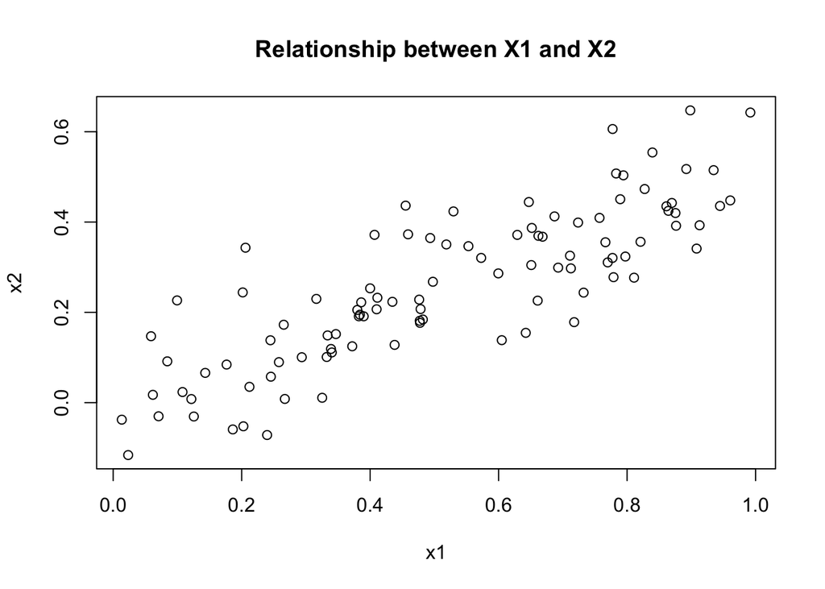

```r
plot(x1, x2, main = "Relationship between X1 and X2")
```

The correlation between $x_1$ and $x_2$ is 0.8351212.

*Part (c)*

```r
lin_fit <- lm(y ~ x1 + x2)
# summary(lin_fit)
```

$x_1$ is significant at p = 0.01, while the adjusted R-squared is 0.1925.

The regression coefficients are: 2.13, 1.43, and 1.01. These coefficients are not close to the true coefficient values. The null hypothesis for $H_0: \beta = 0$ is rejected because p < 0.05. The null hypothesis for $H_0: \beta_2 = 0$ is failed to be rejected because p > 0.05.

*Part (d)*

```r
lin_x1_fit <- lm(y ~ x1)
# summary(lin_x1_fit)
```

x1 is significant, again. The intercept coefficient is 2.1124 and x1 coefficient is 1.9759.

The adjusted R-squared value is 0.1942. The null can be rejected at $H_0: \beta_1 = 0$ because p < 0.05.

*Part (e)*

```r
lin_x2_fit <- lm(y ~ x2)
# summary(lin_x2_fit)
```

The intercept coefficient is 2.3899 and the x2 coefficient is 2.8996. Both are significant at the highest level. The adjusted R-squared value is 0.1679. The null hypothesis $H_0: \beta = 0$ is rejected because p < 0.05.

*Part (f)* The results from c-e are not contradictory. Part (c) includes both x1 and x2 which are collinear together, which impacts the clarity of the role of x1 and x2 in this model on y. In both part (d) and (e) univariate models, the independent variable was significant to the highest level and the R-squared values were similar.

### **Question 5 Chapter 4**

*Part (a)* If the Bayes decision boundary is linear, we expect LDA to perform better on the test set and require less data to get an accurate model. We expect the QDA to perform better on the training set as is it more flexible and it can perform better in the presence of a limited number of training observations.

*Part (b)* If the Bayes decision boundary is non-linear, we expect the QDA to perform better on both the training and test sets. As it assumes a quadratic decision boundary, it can model a wider range of problems.

*Part (c)* As the sample size increases, we expect the test prediction of QDA relative to LDA to improve. As the QDA is very flexible and has a higher variance, so it can result in overfitting with a small sample size. With a larger sample size, as a more flexible model needs more data to produce a better fit.

*Part (d)* False. The QDA would need a lot more sample data to accurately model data with an underlying Bayes linear decision boundary. The flexibility of the QDA can result in overfitting to the training data if there is not a large enough sample size. The LDA could produce a better test prediction with less data.

### **Question 6 Chapter 4**

*Part (a)*

$P(Y) = \frac{exp(-6 + 0.05*40 + 1*3.5)}{[1 + exp(-6 + 0.05*40 + 1*3.5)]}$ $P(Y) = \frac{e^{-0.5}}{(1 + e^{-0.5})} = 0.378$

A student with an undergraduate GPA of 3.5 who studied 40 hours would have a 37.8% chance of getting an A in the statistics course.

*Part (b)*

$$0.5 = \frac{exp(-6 + 0.05*X1 + 1*3.5)}{[1 + exp(-6 + 0.05*X1 + 1*3.5)]}$$
$$0.5 = \frac{exp(-2.5 + 0.05*X1)}{[1 + exp(-2.5 + 0.05*X1)]}$$
$$0.5*[1 + exp(-2.5 + 0.05*X1)]=exp(-2.5 + 0.05*X1)$$
$$0.5 + 0.5*exp(-2.5 + 0.05*X1)=exp(-2.5 + 0.05*X1)$$
$$0.5 = 0.5*exp(-2.5 + 0.05*X1)$$
$$1 = exp(-2.5 + 0.05*X1)$$
$$ln(1) = -2.5 + 0.05*X1$$
$$2.5 = 0.05*X1$$
$$X1 = 50$$

A student with an undergraduate GPA of 3.5 would need to study 50 hours to have a 50% probability of getting an A in the statistics course.

### **Question 5: Ex. 10 (Chapter 4, page 171)**

Weekly percentage returns for the S&P 500 stock index between 1990 and 2010

### **Part a:**

```r
library(ISLR)
weekly <- data.frame(Weekly)
#?Weekly
names(weekly)
```

```
## [1] "Year"      "Lag1"      "Lag2"      "Lag3"      "Lag4"      "Lag5"
## [7] "Volume"    "Today"     "Direction"
```

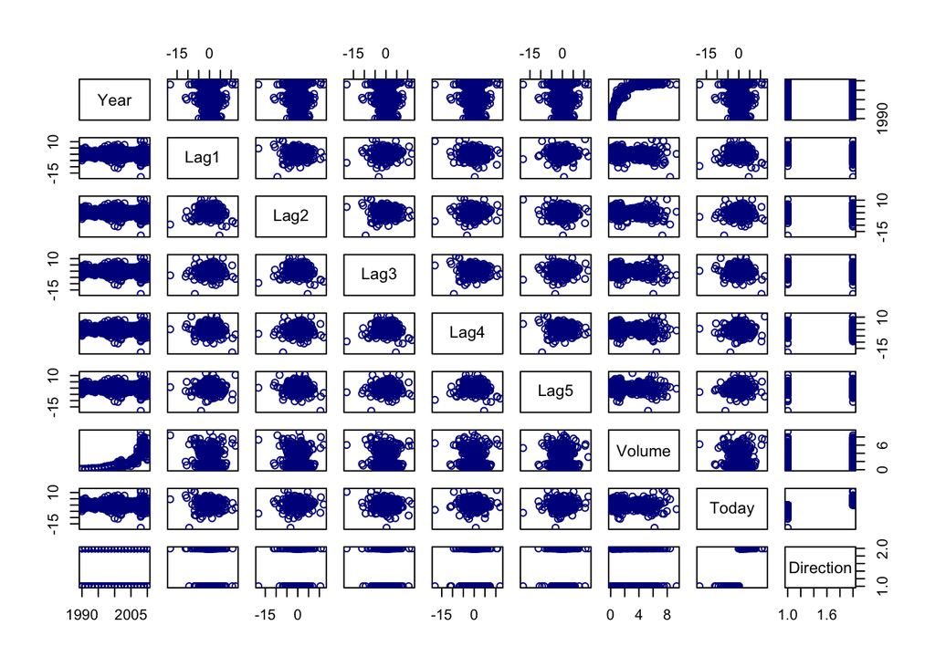

```r
# summary(Weekly)

pairs(weekly,col = "dark blue")
```

The following plot shows the correlation between numeric features. As it is shown, *Year* and *Volume* are highly positively correlated.

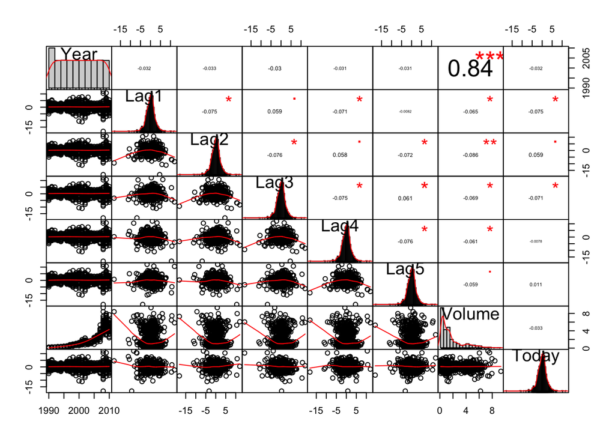

```r
  library(dplyr)
  x <- dplyr::select_if(Weekly, is.numeric)
  dat2 <- x %>% mutate_each_(funs(scale(.) %>% as.vector),
                               vars=c("Weekly$lag1","Weekly$lag2","Weekly$lag3","Weekly$lag4","Weekly$lag5"))
  library("PerformanceAnalytics")
  chart.Correlation(dat2, histogram=TRUE, pch=19)
```

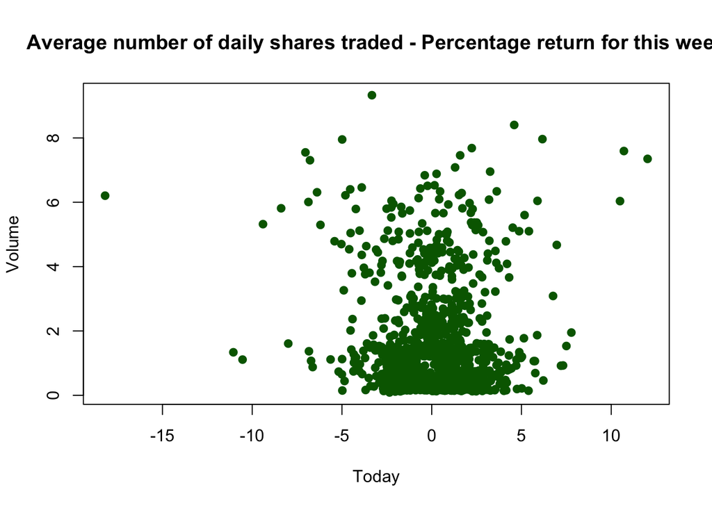

```r
plot(Weekly[,8],Weekly[,7], main="Average number of daily shares traded - Percentage return for this week", xlab="Today", ylab="Volume",col = "dark green", pch=19)
```

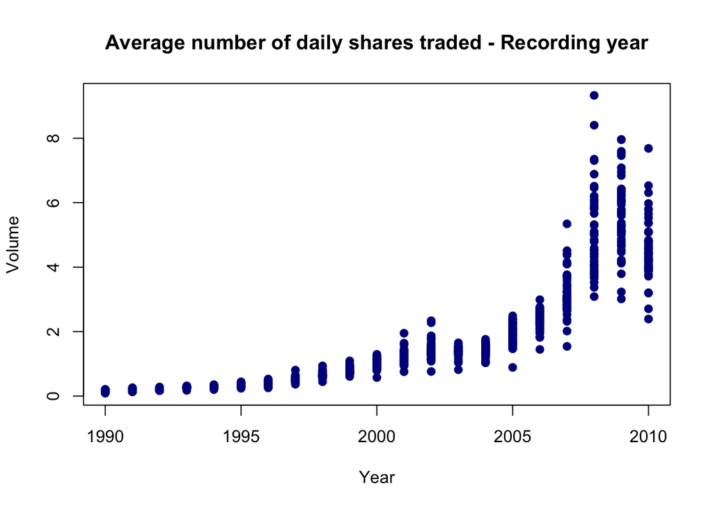

```r
plot(Weekly[,1],Weekly[,7], main="Average number of daily shares traded - Recording year", xlab="Year", ylab="Volume", col = "dark blue", pch=19)
```

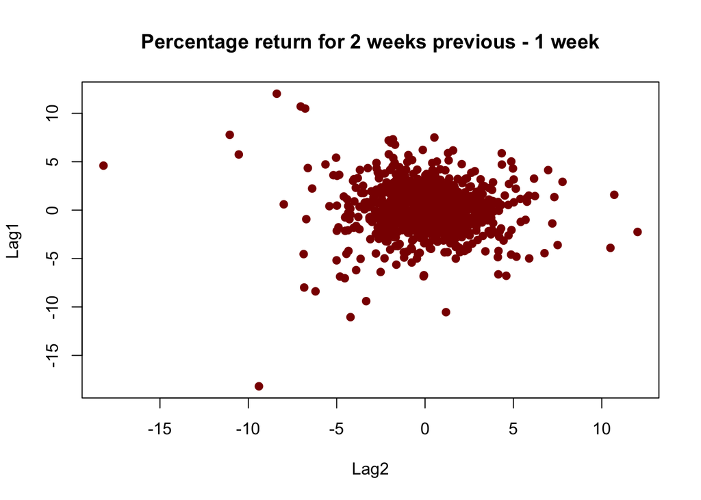

```r
plot(Weekly[,3],Weekly[,2], main="Percentage return for 2 weeks previous - 1 week", xlab="Lag2", ylab="Lag1", col = "dark red", pch=19)
```

### **Part b:** We used the full data set to perform a logistic regression with Direction as the response and the five lag variables plus Volume as predictors. Based on the summary of the fitted logistic model, P-value for the *intercept* and *lag2* is small and the standard deviation is large, which meand we can reject the null hypothesis, and the corrasponding coefficient obtained by logistic regression for intercept and *lag2* is not zero. Thus, there is a substantial association between these feature and the response (Direction). The logistic regression coefficients give the change in the log odds ratio of the outcome for a one unit increase in the predictor variable. For every one unit change in *lag1*, the log odds ration of direction decreases by 0.04127, but *lag1* is not statistically significant. Thus, it does not have any impact on the independant variable, *Direction*. For every one unit change in *lag2*, the log odds ration of direction increases by 0.05844.

```r
Predictors<- data.frame(Weekly[,2:7],Weekly$Direction)

mylogit <- glm(Weekly.Direction ~ Lag1 + Lag2 + Lag3 + Lag4 + Lag5 + Volume , data = Predictors, family = "binomial")

# summary(mylogit)
```

```r
par(mfrow=c(2,2))
# plot(mylogit)
Betacoeff = coef(mylogit)
exp(coef(mylogit))
```

```
## (Intercept)        Lag1        Lag2        Lag3        Lag4        Lag5
##   1.3058630   0.9595710   1.0601831   0.9840671   0.9725924   0.9856322
##      Volume
##   0.9775151
```

The odds ratio and the confidence interval of each predictor as follows:

```r
exp(cbind(OR = coef(mylogit), confint(mylogit)))
```

```
##                    OR     2.5 %   97.5 %
## (Intercept) 1.3058630 1.1038552 1.546201
## Lag1        0.9595710 0.9107589 1.010346
## Lag2        1.0601831 1.0062168 1.118175
## Lag3        0.9840671 0.9336498 1.036701
## Lag4        0.9725924 0.9231603 1.024307
## Lag5        0.9856322 0.9356675 1.037817
## Volume      0.9775151 0.9093257 1.051054
```

Another important information in the Summary of the model is “Residual deviance”, and “AIC”, AIC computes the Err.  
Confidance interval of the model is as follows:

```r
  confint(mylogit)
```

```
##                    2.5 %     97.5 %
## (Intercept)  0.098808746 0.43580101
## Lag1        -0.093477110 0.01029269
## Lag2         0.006197597 0.11169774
## Lag3        -0.068653910 0.03604309
## Lag4        -0.079952378 0.02401603
## Lag5        -0.066495108 0.03711989
## Volume      -0.095051949 0.04979338
```

The test statistic is distributed chi-squared with degrees of freedom equal to the differences in degrees of freedom between the current and the null model (i.e., the number of predictor variables in the model). To find the difference in deviance for the two models (i.e., the test statistic) we can use the command: Null deviance shows fitting a model with just an intercept (e.g. Nulll model).

```r
  with(mylogit, null.deviance - deviance)
```

```
## [1] 9.845236
```

To find the difference in deviance for the two models (i.e., the test statistic) we can use the command:

```r
  with(mylogit, null.deviance - deviance)
```

```
## [1] 9.845236
```

The number of degree of freedom in model is:

```r
  with(mylogit, df.null - df.residual)
```

```
## [1] 6
```

The P-value of the model can be obtained as follows:

```r
  with(mylogit, pchisq(null.deviance - deviance, df.null - df.residual, lower.tail = FALSE))
```

```
## [1] 0.1313226
```

### **Part c:**

```r
  predTrn=predict(mylogit, Predictors, type="response")
  predTrn = ifelse(predTrn < .5, "Down", "Up")
  table(pred = predTrn, true=Weekly$Direction)
```

```
##       true
## pred   Down  Up
##   Down   54  48
##   Up    430 557
```

The confusion matrix is shown as follows. Also this plot shows the predictions from the “predict” function and the color describes whether it was correct or not The explanation is that is seems like the logistic regression primarily guesses “UP” so there are more “Down” predictions wrong than up.

```r
library(caret)

  ## Here I use the predict function:
  Prob = predict(mylogit,type = "response")
  ProbFactor = rep("Up",1089)   #initialize the vector or Up/Down
  ProbFactor[Prob<0.5] = "Down" #change the prediction accordingly
  ProbFactor = factor(ProbFactor)

  ## Here is the part for the figure:
  tab<-table(ProbFactor,Weekly$Direction) #Need a table
  cm<-confusionMatrix(ProbFactor,Weekly$Direction) #Construct the confusion matrix
  cm$table #This prints the table
```

```
##           Reference
## Prediction Down  Up
##       Down   54  48
##       Up    430 557
```

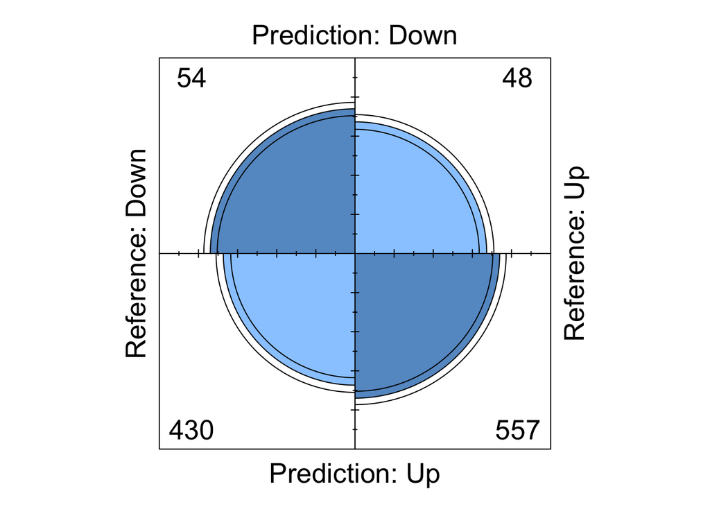

```r
  fourfoldplot(cm$table)
```

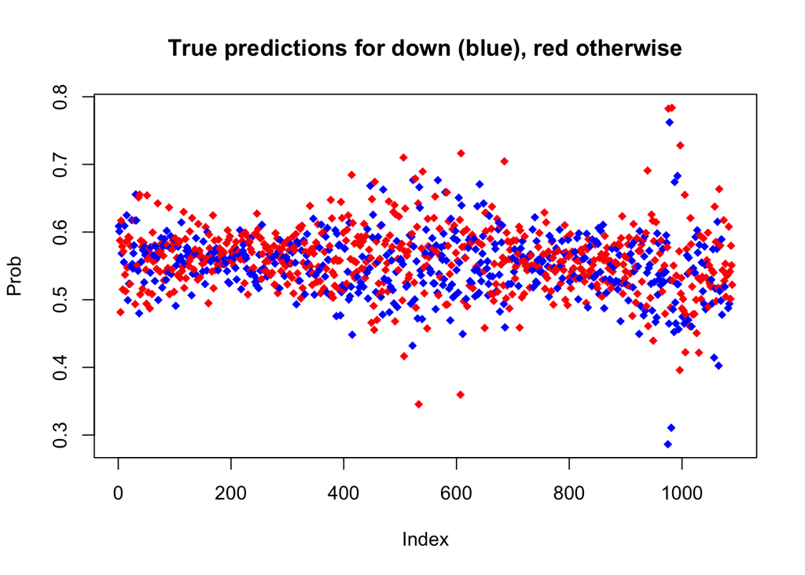

```r
  plot(Prob, col = ifelse(Weekly$Direction == "Down", "blue","red"), pch = 18,
     main="True predictions for down (blue), red otherwise")
```

```r
  correctPredictionslogReg <-sum(diag(tab))/sum(tab)
  incorrectPredictionslogReg <-(tab[1,2]+tab[2,1])/sum(tab)
```

## **Part d:**

In the following we again fit the logistic regression model with only one predictor *(log2)* and same training data but only for years from 1990 to 2008 rather than part a,b from 2009 and 2010.

```r
  Predictors$Year = Weekly$Year
  PredYearTrunc_train <- Predictors[Predictors$Year<= 2008,]
  PredYearTrunc_test <- Predictors[Predictors$Year> 2008,]
  mylogit2 <- glm(Weekly.Direction ~ Lag2, data = PredYearTrunc_train, family = "binomial")
  # summary(mylogit2)
```

One of the errors that we can report for this cathegorical classification type modelings is confusion matrix. The confusion matrix has the number of correct predictions for each class on its diagonal and its offdiagonal values are the misclassifications for every corresponding class. Confusion matrix for truncated years (1990-2008) of both train and test sets are as follows:

```r
  library(lattice)
  library(ggplot2)
  library(caret)
  ## Confusion matrix for truncated years ::: Train set
  predTrn2 = predict(mylogit2, PredYearTrunc_train, type="response")
  predTrn2 = ifelse(predTrn2 < .5, "Down", "Up")
  a <- table(pred = predTrn2, true=PredYearTrunc_train$Weekly.Direction)
  print(a)
```

```
##       true
## pred   Down  Up
##   Down   23  20
##   Up    418 524
```

```r
  MisclassfyLogit_Train = a[1,2]+a[2,1]; print(MisclassfyLogit_Train)
```

```
## [1] 438
```

```r
  confusionMatrix(a)
```

```
## Confusion Matrix and Statistics
##
##       true
## pred   Down  Up
##   Down   23  20
##   Up    418 524
##
##                Accuracy : 0.5553
##                  95% CI : (0.5237, 0.5867)
##     No Information Rate : 0.5523
##     P-Value [Acc > NIR] : 0.4368
##
##                   Kappa : 0.0168
##
##  Mcnemar's Test P-Value : <2e-16
##
##             Sensitivity : 0.05215
##             Specificity : 0.96324
##          Pos Pred Value : 0.53488
##          Neg Pred Value : 0.55626
##              Prevalence : 0.44772
##          Detection Rate : 0.02335
##    Detection Prevalence : 0.04365
##       Balanced Accuracy : 0.50769
##
##        'Positive' Class : Down
##
```

```r
  ## Confusion matrix for truncated years ::: Test set
  predTest2 = predict(mylogit2, PredYearTrunc_test, type="response")
  predTest2 = ifelse(predTest2 < .5, "Down", "Up")
  b <- table(pred = predTest2, true=PredYearTrunc_test$Weekly.Direction)
  print(b)
```

```
##       true
## pred   Down Up
##   Down    9  5
##   Up     34 56
```

```r
  MisclassfyLogit_Test = b[1,2]+b[2,1]; print(MisclassfyLogit_Test)
```

```
## [1] 39
```

```r
  confusionMatrix(b)
```

```
## Confusion Matrix and Statistics
##
##       true
## pred   Down Up
##   Down    9  5
##   Up     34 56
##
##                Accuracy : 0.625
##                  95% CI : (0.5247, 0.718)
##     No Information Rate : 0.5865
##     P-Value [Acc > NIR] : 0.2439
##
##                   Kappa : 0.1414
##
##  Mcnemar's Test P-Value : 7.34e-06
##
##             Sensitivity : 0.20930
##             Specificity : 0.91803
##          Pos Pred Value : 0.64286
##          Neg Pred Value : 0.62222
##              Prevalence : 0.41346
##          Detection Rate : 0.08654
##    Detection Prevalence : 0.13462
##       Balanced Accuracy : 0.56367
##
##        'Positive' Class : Down
##
```

Now:

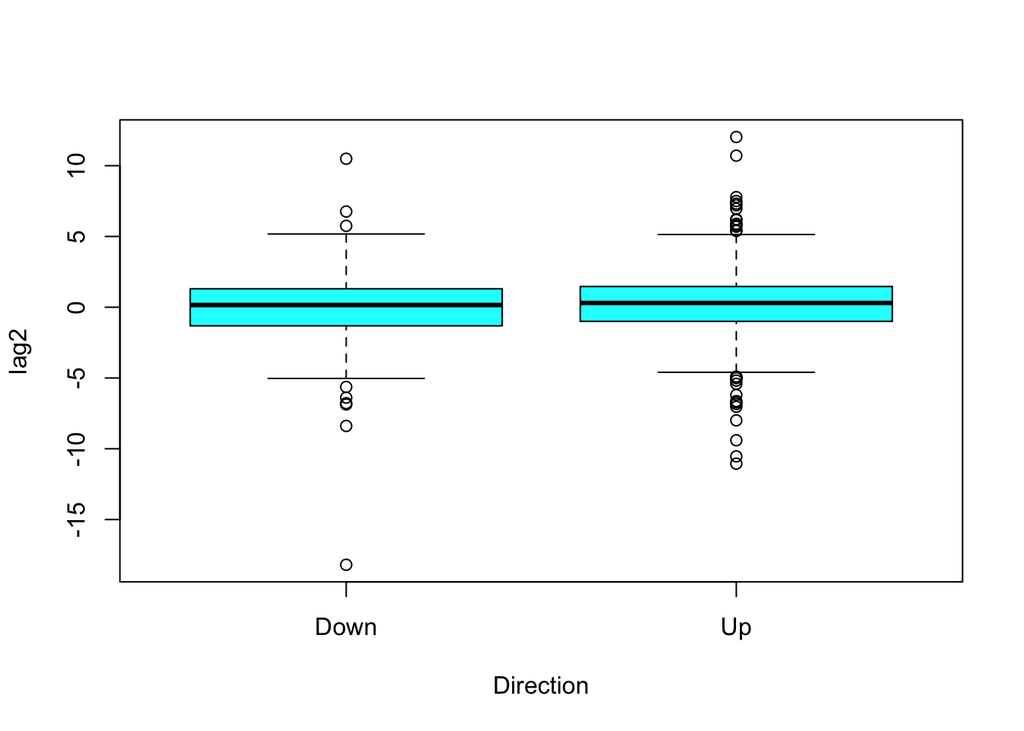

```r
  # par(mfrow=c(2,2))
  # plot(mylogit2)
  plot( Weekly[,9],Weekly[,3],xlab = "Direction", ylab="lag2",col="cyan")
```

Log2 and intercept are both statistically significant, there is a substantial association between predictor, log2 and Direction in the Weekly data set.

## **Part e:**

In this part, we fit LDA (linear discriminate analysis) model to the same data in the part *d*. Then we will compare the confusion matrix of the test and train set for the LDA model with having *lag 2* as the only feature and *Direction* as the response.

```r
  library(MASS)
  myLDA <- lda(Weekly.Direction~Lag2, data= PredYearTrunc_train)
  print(myLDA)
```

```
## Call:
## lda(Weekly.Direction ~ Lag2, data = PredYearTrunc_train)
##
## Prior probabilities of groups:
##      Down        Up
## 0.4477157 0.5522843
##
## Group means:
##             Lag2
## Down -0.03568254
## Up    0.26036581
##
## Coefficients of linear discriminants:
##            LD1
## Lag2 0.4414162
```

```r
  ## confidance interval for LDA
  confint(mylogit)
```

```
##                    2.5 %     97.5 %
## (Intercept)  0.098808746 0.43580101
## Lag1        -0.093477110 0.01029269
## Lag2         0.006197597 0.11169774
## Lag3        -0.068653910 0.03604309
## Lag4        -0.079952378 0.02401603
## Lag5        -0.066495108 0.03711989
## Volume      -0.095051949 0.04979338
```

```r
  coef(myLDA)
```

```
##            LD1
## Lag2 0.4414162
```

The confusion matrix for train and test set in LDA is as follows:

```r
  ## Confusion matrix for truncated years ::: Train set
  predTrn2 = predict(myLDA, PredYearTrunc_train, type="response")$class
  a <- table(pred = predTrn2, true=PredYearTrunc_train$Weekly.Direction)
  print(a)
```

```
##       true
## pred   Down  Up
##   Down   22  20
##   Up    419 524
```

```r
  confusionMatrix(a)
```

```
## Confusion Matrix and Statistics
##
##       true
## pred   Down  Up
##   Down   22  20
##   Up    419 524
##
##                Accuracy : 0.5543
##                  95% CI : (0.5226, 0.5857)
##     No Information Rate : 0.5523
##     P-Value [Acc > NIR] : 0.4622
##
##                   Kappa : 0.0144
##
##  Mcnemar's Test P-Value : <2e-16
##
##             Sensitivity : 0.04989
##             Specificity : 0.96324
##          Pos Pred Value : 0.52381
##          Neg Pred Value : 0.55567
##              Prevalence : 0.44772
##          Detection Rate : 0.02234
##    Detection Prevalence : 0.04264
##       Balanced Accuracy : 0.50656
##
##        'Positive' Class : Down
##
```

```r
  MisclassfyLDA_Train = a[1,2]+a[2,1]; print(MisclassfyLDA_Train)
```

```
## [1] 439
```

```r
  ## Confusion matrix for truncated years ::: Test set
  predTest2 = predict(myLDA, PredYearTrunc_test, type="response")$class
  b <- table(pred = predTest2, true=PredYearTrunc_test$Weekly.Direction)
  print(b)
```

```
##       true
## pred   Down Up
##   Down    9  5
##   Up     34 56
```

```r
  MisclassfyLDA_Test = b[1,2]+b[2,1]; print(MisclassfyLDA_Test)
```

```
## [1] 39
```

```r
  # LDA:
  #Get LDA prediction
  ldaPred = predict(myLDA, type="response", newdata=PredYearTrunc_test)
  ldaClass = ldaPred$class
  #Confusion Mx
  tab<-table(ldaClass,PredYearTrunc_test$Weekly.Direction)
  cm<-confusionMatrix(ldaClass,PredYearTrunc_test$Weekly.Direction)
  cm$table
```

```
##           Reference
## Prediction Down Up
##       Down    9  5
##       Up     34 56
```

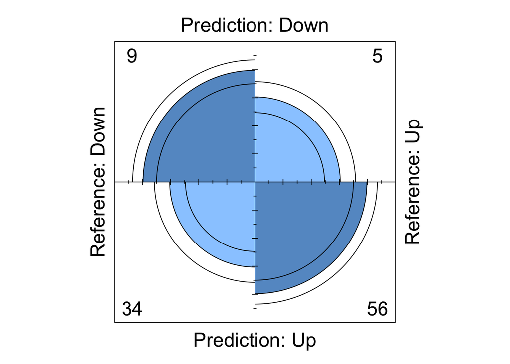

```r
  fourfoldplot(cm$table)
```

```r
  #Correct predictions LDA:
  correctPredictionsLDA <-sum(diag(tab))/sum(tab)
  incorrectPredictionsLDA <-(tab[1,2]+tab[2,1])/sum(tab)
```

### **Part f:**

We fit the QDA (Quadratic discriminate analysis) on the same data as part *(d, e)*:

```r
  myQDA <- qda(Weekly.Direction ~ Lag2, data = PredYearTrunc_train)
  print(myQDA)
```

```
## Call:
## qda(Weekly.Direction ~ Lag2, data = PredYearTrunc_train)
##
## Prior probabilities of groups:
##      Down        Up
## 0.4477157 0.5522843
##
## Group means:
##             Lag2
## Down -0.03568254
## Up    0.26036581
```

```r
  confint(mylogit)
```

```
##                    2.5 %     97.5 %
## (Intercept)  0.098808746 0.43580101
## Lag1        -0.093477110 0.01029269
## Lag2         0.006197597 0.11169774
## Lag3        -0.068653910 0.03604309
## Lag4        -0.079952378 0.02401603
## Lag5        -0.066495108 0.03711989
## Volume      -0.095051949 0.04979338
```

```r
  coef(myLDA)
```

```
##            LD1
## Lag2 0.4414162
```

We also show the decision boundaries (parabolas) of QDA by projecting the data points into 2D. In the following plot correct predictions for *Direction* (response) including *Up, Down* is showing by blue, and wrong predictions are shown by red color. In addition, the nonlinear (quadratic) decision boundaries are shown in magnet and cyan colors.

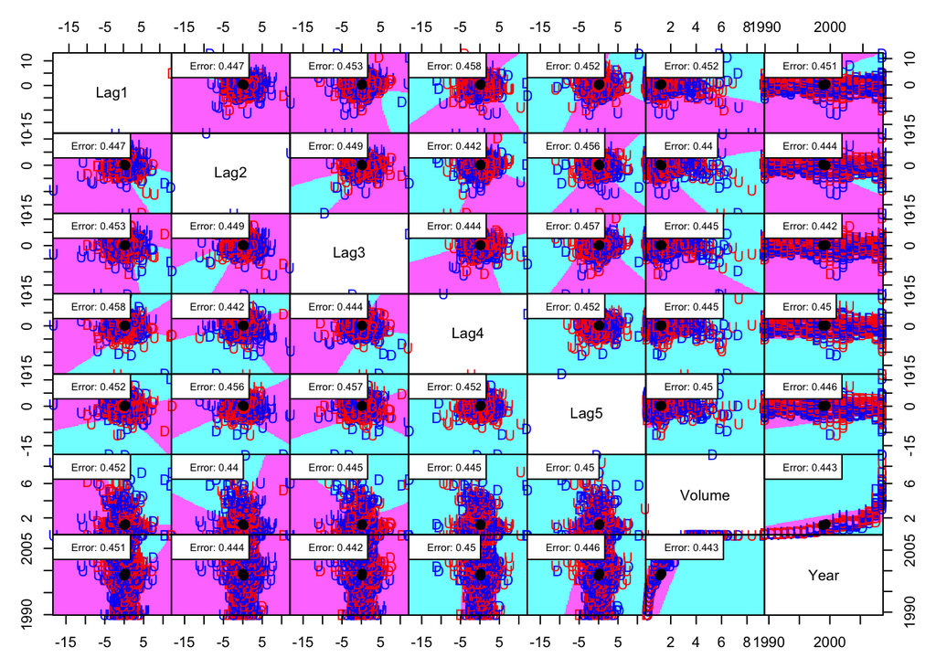

```r
  library(klaR)
  partimat(PredYearTrunc_train$Weekly.Direction ~ ., data = PredYearTrunc_train, method = "qda", plot.matrix = TRUE, col.correct='blue', col.wrong='red')
```

QDA misclassification error:

```r
    ## Confusion matrix for truncated years ::: Train set
  predTrn2 = predict(myQDA, PredYearTrunc_train, type="response")$class
  a <- table(pred = predTrn2, true=PredYearTrunc_train$Weekly.Direction)
  print(a)
```

```
##       true
## pred   Down  Up
##   Down    0   0
##   Up    441 544
```

```r
  confusionMatrix(a)
```

```
## Confusion Matrix and Statistics
##
##       true
## pred   Down  Up
##   Down    0   0
##   Up    441 544
##
##                Accuracy : 0.5523
##                  95% CI : (0.5206, 0.5836)
##     No Information Rate : 0.5523
##     P-Value [Acc > NIR] : 0.5132
##
##                   Kappa : 0
##
##  Mcnemar's Test P-Value : <2e-16
##
##             Sensitivity : 0.0000
##             Specificity : 1.0000
##          Pos Pred Value :    NaN
##          Neg Pred Value : 0.5523
##              Prevalence : 0.4477
##          Detection Rate : 0.0000
##    Detection Prevalence : 0.0000
##       Balanced Accuracy : 0.5000
##
##        'Positive' Class : Down
##
```

```r
  MisclassfyQDA_Train = a[1,2]+a[2,1]; print(MisclassfyQDA_Train)
```

```
## [1] 441
```

```r
  ## Confusion matrix for truncated years ::: Test set
  predTest2 = predict(myQDA, PredYearTrunc_test, type="response")$class
  b <- table(pred = predTest2, true=PredYearTrunc_test$Weekly.Direction)
  print(b)
```

```
##       true
## pred   Down Up
##   Down    0  0
##   Up     43 61
```

```r
  MisclassfyQDA_Test = b[1,2]+b[2,1]; print(MisclassfyQDA_Test)
```

```
## [1] 43
```

```r
  # QDA
  #Get QDA prediction
  qdaPred = predict(myQDA, type="response", newdata = PredYearTrunc_test)
  qdaFit = qdaPred$class
  #Confusion Mx QDA
  tab<-table(qdaFit,PredYearTrunc_test$Weekly.Direction)
  cm<-confusionMatrix(qdaFit,PredYearTrunc_test$Weekly.Direction)
  cm$table
```

```
##           Reference
## Prediction Down Up
##       Down    0  0
##       Up     43 61
```

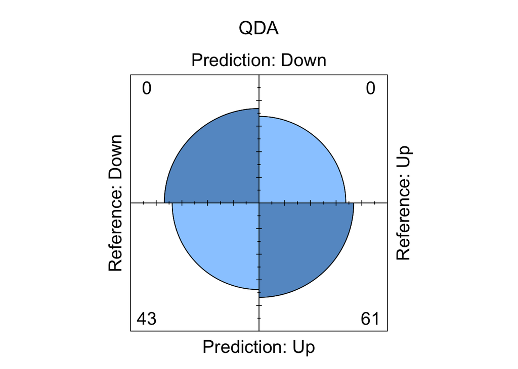

```r
  fourfoldplot(cm$table, main = "QDA")
```

```r
  #Correct predictions QDA:
  correctPredictionsQDA <-sum(diag(tab))/sum(tab)
  print(correctPredictionsQDA)
```

```
## [1] 0.5865385
```

```r
  incorrectPredictionsQDA <-(tab[1,2]+tab[2,1])/sum(tab)
  print(incorrectPredictionsQDA)
```

```
## [1] 0.4134615
```

### **Part g:**

We fit the KNN with K=1 (K nearest neighbors) on the same data as part *(d, e, f)*:

```r
  library("class")
  library(caret)

  obs <- nrow(PredYearTrunc_train)
  obsTest <- nrow(PredYearTrunc_test)

  test.myKNN <- knn(train=PredYearTrunc_train[1:6], test=PredYearTrunc_test[1:6],       PredYearTrunc_train$Weekly.Direction, k=1)
  # train.error <- sum(train.myKNN != PredYearTrunc_train$Weekly.Direction)/obs
  # print(train.error)

  a <- table(test.myKNN, PredYearTrunc_test$Weekly.Direction)

  print(a)
```

```
##
## test.myKNN Down Up
##       Down   21 32
##       Up     22 29
```

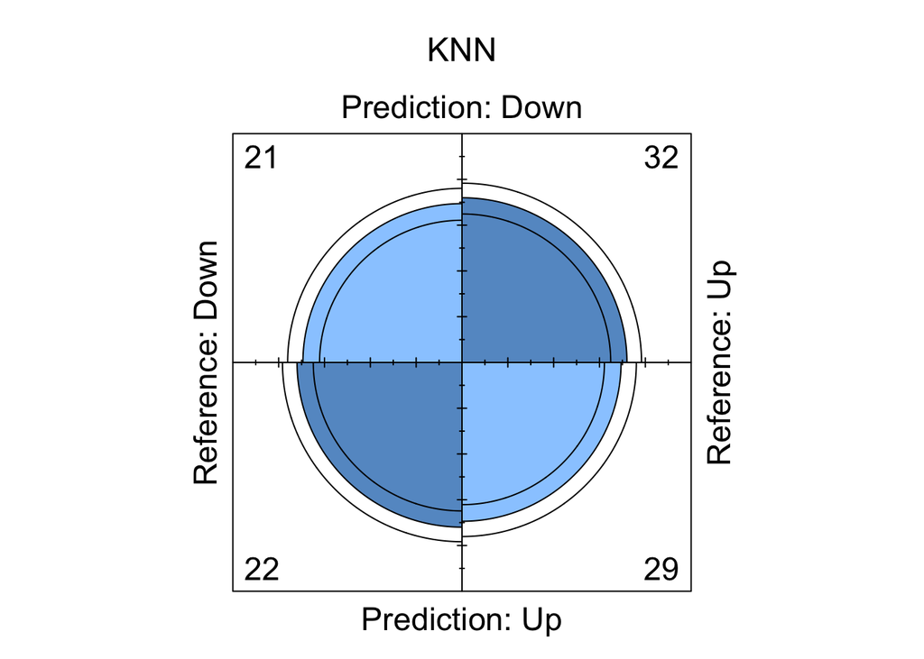

```r
  cm<-confusionMatrix(test.myKNN,PredYearTrunc_test$Weekly.Direction)
  fourfoldplot(cm$table,main = "KNN")
```

```r
  correctPredictionsKNN <-sum(diag(a))/sum(a)
  incorrectPredictionsKNN <-(a[1,2]+a[2,1])/sum(a)
  Misclassfytest.myKNN = a[1,2]+a[2,1]; print(Misclassfytest.myKNN)
```

```
## [1] 54
```

KNN misclassification error is as follows:

```r
  train.myKNN <- knn(train=PredYearTrunc_train[1:6], test=PredYearTrunc_train[1:6],  PredYearTrunc_train$Weekly.Direction, k=1)

  a <- table(train.myKNN, PredYearTrunc_train$Weekly.Direction)
  print(a)
```

```
##
## train.myKNN Down  Up
##        Down  441   0
##        Up      0 544
```

```r
  confusionMatrix(train.myKNN,PredYearTrunc_train$Weekly.Direction)
```

```
## Confusion Matrix and Statistics
##
##           Reference
## Prediction Down  Up
##       Down  441   0
##       Up      0 544
##
##                Accuracy : 1
##                  95% CI : (0.9963, 1)
##     No Information Rate : 0.5523
##     P-Value [Acc > NIR] : < 2.2e-16
##
##                   Kappa : 1
##
##  Mcnemar's Test P-Value : NA
##
##             Sensitivity : 1.0000
##             Specificity : 1.0000
##          Pos Pred Value : 1.0000
##          Neg Pred Value : 1.0000
##              Prevalence : 0.4477
##          Detection Rate : 0.4477
##    Detection Prevalence : 0.4477
##       Balanced Accuracy : 1.0000
##
##        'Positive' Class : Down
##
```

```r
  Misclassfytrain.myKNN = a[1,2]+a[2,1]; print(Misclassfytrain.myKNN)
```

```
## [1] 0
```

### **Part h:**

```r
  TrainMissClassification = c(MisclassfyLogit_Train,MisclassfyLDA_Train,MisclassfyQDA_Train,Misclassfytrain.myKNN)
print(TrainMissClassification)
```

```
## [1] 438 439 441   0
```

```r
  TestMissClassification = c(MisclassfyLogit_Test,MisclassfyLDA_Test,MisclassfyQDA_Test,Misclassfytest.myKNN)
  print(TestMissClassification)
```

```
## [1] 39 39 43 54
```

[output not shown]

### **Part i:**

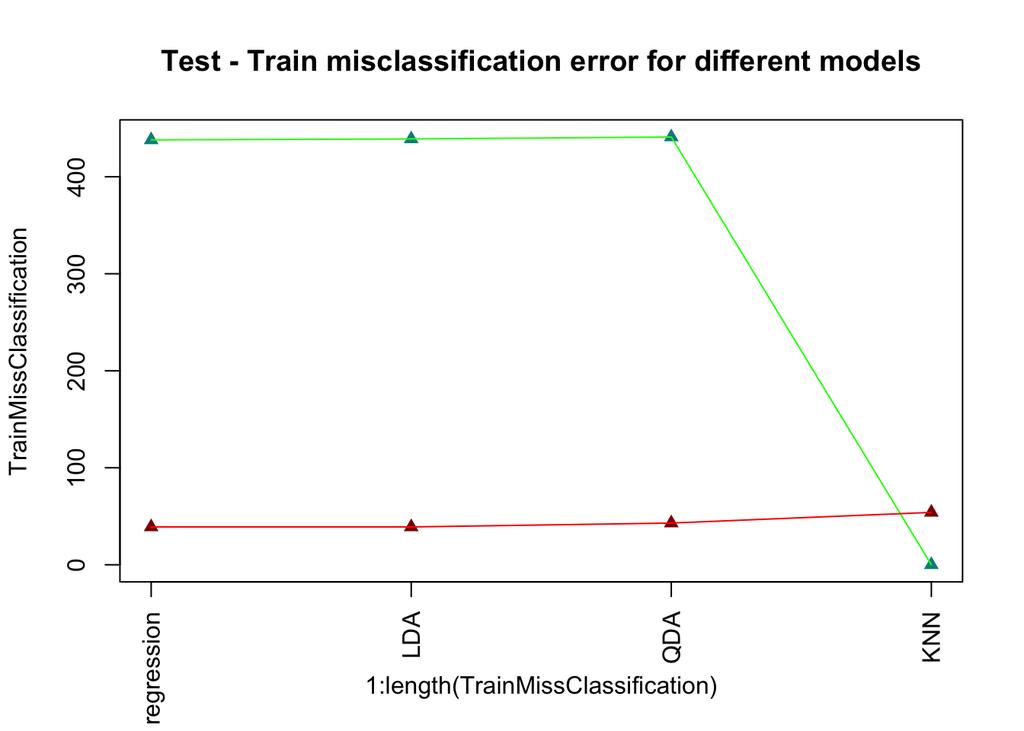

```r
  plot(1:length(TrainMissClassification),TrainMissClassification, type = 'p', col="dark cyan", pch=17, axes=F)
  lines(1:length(TrainMissClassification),TrainMissClassification,col="green")
  points(1:length(TestMissClassification),TestMissClassification, type = 'p', col="dark red", pch=17)
  lines(1:length(TestMissClassification),TestMissClassification,col="red")
  box(lty = 'solid', col = 'black')
  title(main = "Test - Train misclassification error for different models")
  legend(3.2, 560, legend=c("Train error", "Test error"), col=c("green", "red"), lty="solid", cex=1)
  axis(1, at=1:4, labels = c('Logistic regression','LDA','QDA','KNN'), las=2)
  axis(2)
```

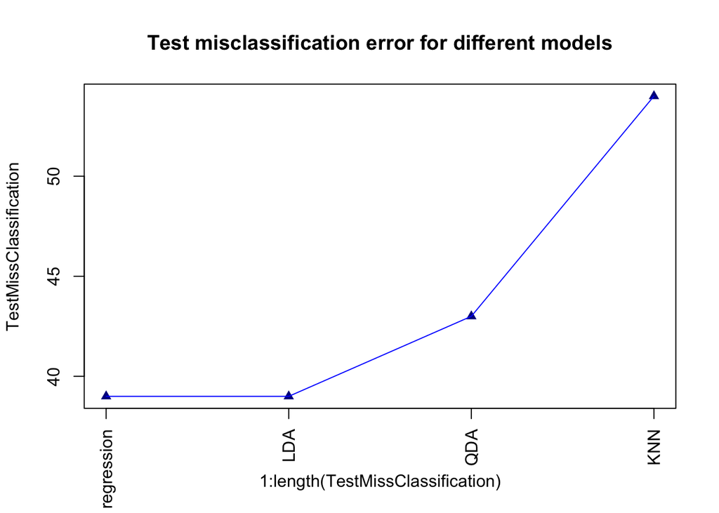

```r
  plot(1:length(TestMissClassification),TestMissClassification, type = 'p', col="dark blue", pch=17,axes=F)
  lines(1:length(TestMissClassification),TestMissClassification,col="blue")
  box(lty = 'solid', col = 'black')
  title(main = "Test misclassification error for different models")
  axis(1, at=1:4, labels = c('Logistic regression','LDA','QDA','KNN'), las=2)
  axis(2)
```